# Midwest Sales Bayesian Data Analysis

*Analysis conducted by: Arvind Kumar (ID:18274348) and Jahnavi Maddhuri (ID:19419918)*

```r
# load required libraries
library(tidyverse)
library(bayesrules)
library(rstanarm)
```

```r
library(bayesplot)
# load midwest data frame
midwest <- read.csv("MidwestSales.txt", sep="")
```

# **1.) Hypothesis Testing**

Conduct a hypothesis test for the proportion of houses with AC (Air Conditioning).

$H_0: \pi \leq 0.8$  
$H_A: \pi > 0.8$

## Prior

According to the US Energy of Information Administration, 87% of houses have some form of air conditioning as of 2009. We used this information in formulating our prior so as to ensure that the median of our chosen beta distribution is around 0.85.

**Beta Distribution:**

alpha = 17

beta = 3

$\pi \sim Beta(\alpha = 17, \beta = 3)$

## Likelihood

```r
set.seed(84735) #set seed for ability to reproduce sampling

# Creating data frame for 100 samples of midwest data + filtering
#   for houses with ac
midwest_sample = midwest %>%
  sample_n(100)
midwest_sample = midwest_sample %>%
  filter(ac == 1)
nrow(midwest_sample) #count number of successes
```

```
## [1] 82
```

**Sample Data Outcome (Likelihood):**

x = 82

n = 100

## Posterior

```r
# Find posterior distribution based on prior + likelihood
summarize_beta_binomial(alpha = 17, beta = 3, x = 82, n = 100)
```

```
##       model alpha beta  mean      mode         var
## 1     prior    17    3 0.850 0.8888889 0.006071429
## 2 posterior    99   21 0.825 0.8305085 0.001193182
```

**Posterior alpha and beta:**

p_alpha = 99

p_beta = 21

$\pi|X \sim Beta(\alpha = 99, \beta = 21)$

## Calculating Bayes Factor

### PRIOR PLOT

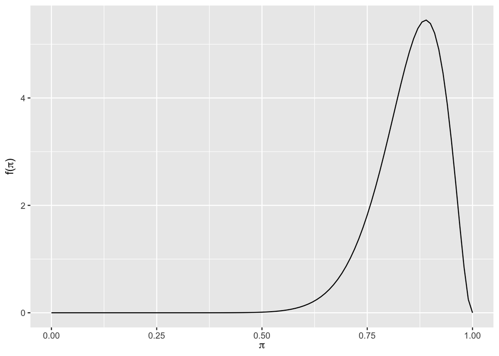

```r
bayesrules::plot_beta(17,3)
```

### POSTERIOR PLOT

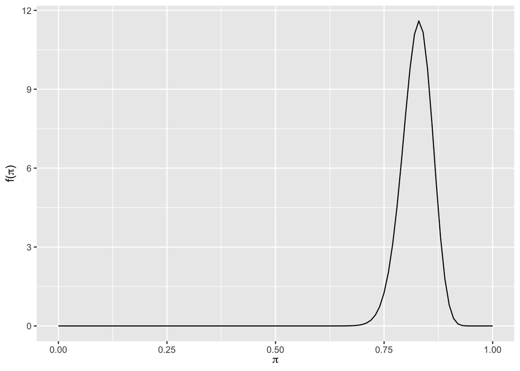

```r
plot_beta(99,21)
```

### Calculating Posterior Odds and Probability

```r
posterior_prob = pbeta(0.8, 99, 21, lower.tail = FALSE)
```

Posterior Odds = $\frac{P(H_A|x = 82)}{P(H_0|x = 82)}$

```r
posterior_odds = posterior_prob/(1-posterior_prob)
posterior_odds
```

```
## [1] 3.390682
```

### Calculating Prior Odds and Probability

```r
prior_prob = pbeta(0.8, 17, 3, lower.tail = FALSE)
prior_odds = prior_prob/(1-prior_prob)
prior_odds
```

```
## [1] 3.22138
```

### Calculating Bayes’ Factor

```r
bayes_factor = posterior_odds/prior_odds
bayes_factor
```

```
## [1] 1.052556
```

**Conclusion:** Since our Bayes Factor is greater than one, this implies that the odds of the posterior are greater than the odds of the prior. Since the posterior probability is representative of the odds of the alternate hypothesis over the null hypothesis given the data, we reject the null hypothesis and support the claim that more than 80% of midwest houses have Air Conditioning installed.

# **2.) Credible Intervals**

**Posterior Distribution**

p_alpha = 99

p_beta = 21

$\pi|X \sim Beta(\alpha = 99, \beta = 21)$

### CONFIDENCE INTERVAL PLOT

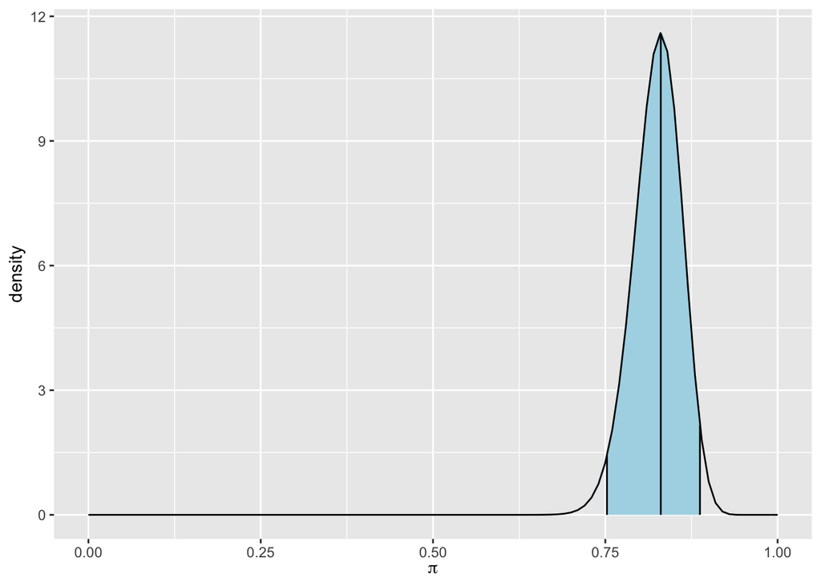

```r
plot_beta_ci(99,21)
```

```r
#Calculating the lower and upper bounds for the credible interval
lower_bound = qbeta(.025, 100,20)
upper_bound = qbeta(.975, 100, 20)
lower_bound
```

```
## [1] 0.7619469
```

```r
upper_bound
```

```
## [1] 0.8942123
```

# **3.) Predictive Modeling**

## Midwest Data Sampling

```r
# Create a data frame of 522 samples
midwest <- midwest %>%
  sample_n(522)


##separate data into test/train data frames
midwest_train <- midwest %>%
  sample_frac(0.80)

midwest_test <- midwest %>%
  anti_join(midwest_train, by = "sqft")
```

## Modeling

```r
# Create a model to predict Price based on Square Foot
normal_model <- stan_glm(Price~sqft,
         data = midwest_train,
         family = gaussian,
         chains = 4, iter = 5000*2)
```

# Plots on Model Parameters

```r
prior_summary(normal_model)
```

```
## Priors for model 'normal_model'
## ------
## Intercept (after predictors centered)
##   Specified prior:
##     ~ normal(location = 280292, scale = 2.5)
##   Adjusted prior:
##     ~ normal(location = 280292, scale = 348833)
##
## Coefficients
##   Specified prior:
##     ~ normal(location = 0, scale = 2.5)
##   Adjusted prior:
##     ~ normal(location = 0, scale = 495)
##
## Auxiliary (sigma)
##   Specified prior:
##     ~ exponential(rate = 1)
##   Adjusted prior:
##     ~ exponential(rate = 7.2e-06)
## ------
## See help('prior_summary.stanreg') for more details
```

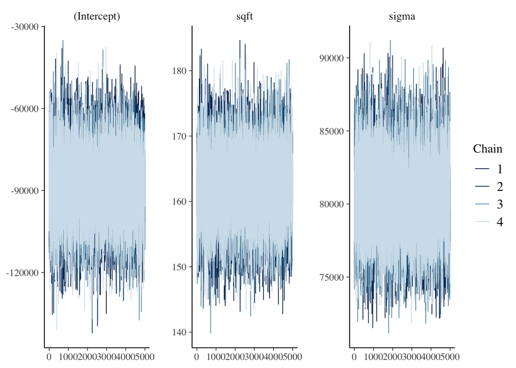

```r
mcmc_trace(normal_model) #trace plots for intercept, slope and sigma
```

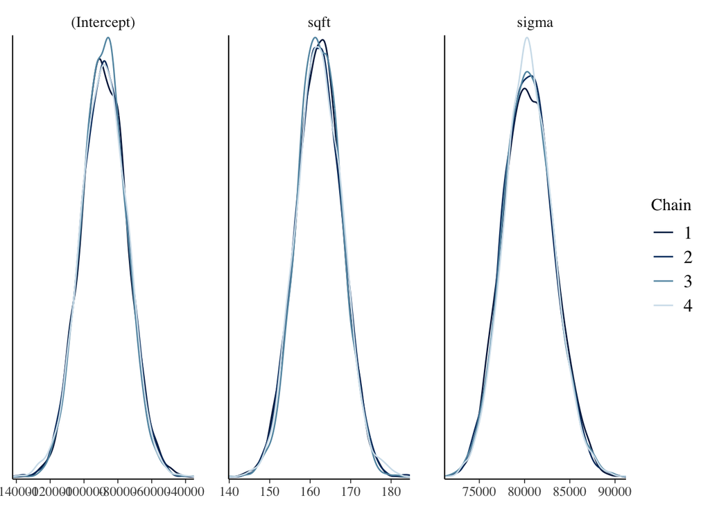

```r
mcmc_dens_overlay(normal_model) #trace plots for intercept, slope and sigma
```

```r
# table manipulation for slope, intercept and sigma approximations
normal_model_df <- as.array(normal_model) %>%
  reshape2::melt() %>%
  pivot_wider(names_from = parameters, values_from = value)

#returns boundaries on the middle 80% of the model parameters
posterior_interval(normal_model, prob = 0.80)
```

```
##                      10%         90%
## (Intercept) -105438.6157 -71116.2345
## sqft            154.9736    169.3816
## sigma         76934.6188  84097.7012
```

```r
#create approximations for the slope, intercept and sigma
b1_mean <- mean(normal_model_df$sqft)
b0_mean <- mean(normal_model_df$`(Intercept)`)
sigma_mean <- mean(normal_model_df$sigma)
```

## Predictive Modeling

```r
# we chose to model on the mean sqft based on the midwest data collection
average_sqft = mean(midwest$sqft)

y_trend <- b0_mean + b1_mean * average_sqft

rnorm(1, y_trend, sigma_mean) # sample from prediction distribution,
```

```
## [1] 269184.5
```

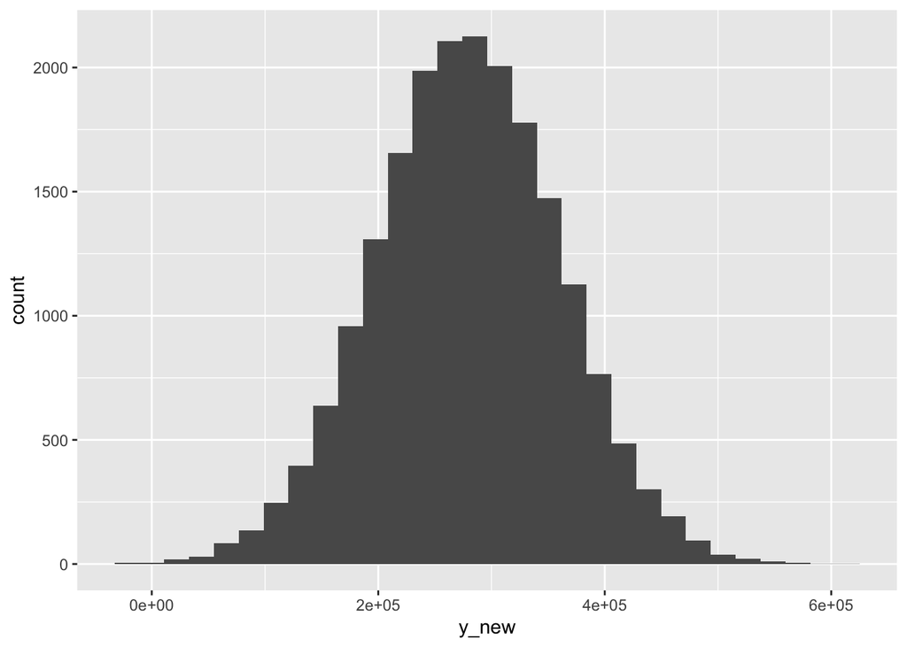

```r
# include y_trend and y_new in prediction data frame
prediction <- normal_model_df %>%
  mutate(y_trend = `(Intercept)` + sqft*average_sqft) %>%
  mutate(y_new = rnorm(20000, y_trend, sigma))

# plot prediction
prediction %>%
  ggplot() + aes(x = y_new) + geom_histogram()
```

```r
summary(prediction) #get summary statistics on prediction
```

```
##    iterations       chains      (Intercept)           sqft
##  Min.   :   1   chain:1:5000   Min.   :-142173   Min.   :139.9
##  1st Qu.:1251   chain:2:5000   1st Qu.: -97304   1st Qu.:158.4
##  Median :2500   chain:3:5000   Median : -88219   Median :162.2
##  Mean   :2500   chain:4:5000   Mean   : -88256   Mean   :162.2
##  3rd Qu.:3750                  3rd Qu.: -79196   3rd Qu.:166.0
##  Max.   :5000                  Max.   : -35034   Max.   :184.7
##      sigma          y_trend           y_new
##  Min.   :71161   Min.   :261499   Min.   :-31610
##  1st Qu.:78537   1st Qu.:275787   1st Qu.:224462
##  Median :80398   Median :278392   Median :278831
##  Mean   :80465   Mean   :278423   Mean   :278868
##  3rd Qu.:82302   3rd Qu.:281071   3rd Qu.:333808
##  Max.   :91208   Max.   :295274   Max.   :604633
```

## Regression Distribution Plot

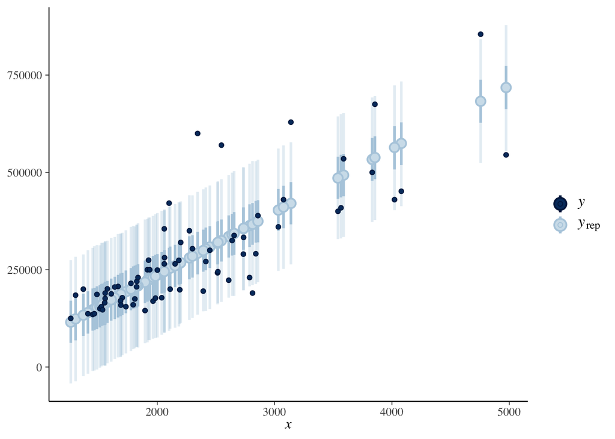

```r
predictions <- posterior_predict(normal_model,
                               newdata = midwest_test)

ppc_intervals(midwest_test$Price,
              yrep = predictions,
              x = midwest_test$sqft,
              prob = 0.5,
              prob_outer = 0.95)
```

```r
bayesrules::prediction_summary(y = midwest_test$Price,
                   yrep = predictions)
```

```
##        mae mae_scaled within_50 within_95
## 1 33575.95  0.4180985 0.6081081 0.9054054
```